# Project: No-show appointments

- Introduction
- Data Wrangling
- Exploratory Data Analysis
- Conclusions

## Introduction

> **Data Set**: No-show appointments dataset collects information from 100k medical appointments in Brazil and is focused on the question of whether or not patients show up for their appointment
- ‘ScheduledDay’ tells us on what day the patient set up their appointment.
- ‘Neighborhood’ indicates the location of the hospital.
- ‘Scholarship’ indicates whether or not the patient is enrolled in Brasilian welfare program.
- ‘No-show’ says ‘No’ if the patient showed up to their appointment, and ‘Yes’ if they did not show up.

```python
import numpy as np
import pandas as pd
import matplotlib.pyplot as plt
import seaborn as sns

% matplotlib inline
```

## Data Wrangling

### Importing the Data

```python
df = pd.read_csv('noshowappointments-kagglev2-may-2016.csv')
```

### Descriptive Summary

```python
df.describe()
```

|  | PatientId | AppointmentID | Age | Scholarship | Hipertension | Diabetes | Alcoholism | Handcap | SMS_received |
| --- | --- | --- | --- | --- | --- | --- | --- | --- | --- |
| count | 1.105270e+05 | 1.105270e+05 | 110527.000000 | 110527.000000 | 110527.000000 | 110527.000000 | 110527.000000 | 110527.000000 | 110527.000000 |
| mean | 1.474963e+14 | 5.675305e+06 | 37.088874 | 0.098266 | 0.197246 | 0.071865 | 0.030400 | 0.022248 | 0.321026 |
| std | 2.560949e+14 | 7.129575e+04 | 23.110205 | 0.297675 | 0.397921 | 0.258265 | 0.171686 | 0.161543 | 0.466873 |
| min | 3.921784e+04 | 5.030230e+06 | -1.000000 | 0.000000 | 0.000000 | 0.000000 | 0.000000 | 0.000000 | 0.000000 |
| 25% | 4.172614e+12 | 5.640286e+06 | 18.000000 | 0.000000 | 0.000000 | 0.000000 | 0.000000 | 0.000000 | 0.000000 |
| 50% | 3.173184e+13 | 5.680573e+06 | 37.000000 | 0.000000 | 0.000000 | 0.000000 | 0.000000 | 0.000000 | 0.000000 |
| 75% | 9.439172e+13 | 5.725524e+06 | 55.000000 | 0.000000 | 0.000000 | 0.000000 | 0.000000 | 0.000000 | 1.000000 |
| max | 9.999816e+14 | 5.790484e+06 | 115.000000 | 1.000000 | 1.000000 | 1.000000 | 1.000000 | 4.000000 | 1.000000 |

```python
df.head()
```

|  | PatientId | AppointmentID | Gender | ScheduledDay | AppointmentDay | Age | Neighbourhood | Scholarship | Hipertension | Diabetes | Alcoholism | Handcap | SMS_received | No-show |
| --- | --- | --- | --- | --- | --- | --- | --- | --- | --- | --- | --- | --- | --- | --- |
| 0 | 2.987250e+13 | 5642903 | F | 2016-04-29T18:38:08Z | 2016-04-29T00:00:00Z | 62 | JARDIM DA PENHA | 0 | 1 | 0 | 0 | 0 | 0 | No |
| 1 | 5.589978e+14 | 5642503 | M | 2016-04-29T16:08:27Z | 2016-04-29T00:00:00Z | 56 | JARDIM DA PENHA | 0 | 0 | 0 | 0 | 0 | 0 | No |
| 2 | 4.262962e+12 | 5642549 | F | 2016-04-29T16:19:04Z | 2016-04-29T00:00:00Z | 62 | MATA DA PRAIA | 0 | 0 | 0 | 0 | 0 | 0 | No |
| 3 | 8.679512e+11 | 5642828 | F | 2016-04-29T17:29:31Z | 2016-04-29T00:00:00Z | 8 | PONTAL DE CAMBURI | 0 | 0 | 0 | 0 | 0 | 0 | No |
| 4 | 8.841186e+12 | 5642494 | F | 2016-04-29T16:07:23Z | 2016-04-29T00:00:00Z | 56 | JARDIM DA PENHA | 0 | 1 | 1 | 0 | 0 | 0 | No |

### Data Cleaning (Remove typos)

```python
df.rename(columns = {'Hipertension': 'Hypertension',
                'Handcap': 'Handicap','No-show':'No_show'}, inplace = True)

print(df.columns)
```

```
Index(['PatientId', 'AppointmentID', 'Gender', 'ScheduledDay',
       'AppointmentDay', 'Age', 'Neighbourhood', 'Scholarship', 'Hypertension',
       'Diabetes', 'Alcoholism', 'Handicap', 'SMS_received', 'No_show'],
      dtype='object')
```

### Checking for erroneous values and NaNs

```python
print('Age:',sorted(df.Age.unique()))
print('Gender:',df.Gender.unique())
print('Diabetes:',df.Diabetes.unique())
print('Alcoholism:',df.Alcoholism.unique())
print('Hypertension:',df.Hypertension.unique())#Hypertension
print('Handicap:',df.Handicap.unique())#Handicap
print('Scholarship:',df.Scholarship.unique())
print('SMS_received:',df.SMS_received.unique())
print('No_show:',df.No_show.unique())
```

```
Age: [-1, 0, 1, 2, 3, 4, 5, 6, 7, 8, 9, 10, 11, 12, 13, 14, 15, 16, 17, 18, 19, 20, 21, 22, 23, 24, 25, 26, 27, 28, 29, 30, 31, 32, 33, 34, 35, 36, 37, 38, 39, 40, 41, 42, 43, 44, 45, 46, 47, 48, 49, 50, 51, 52, 53, 54, 55, 56, 57, 58, 59, 60, 61, 62, 63, 64, 65, 66, 67, 68, 69, 70, 71, 72, 73, 74, …
Gender: ['F' 'M']
Diabetes: [0 1]
Alcoholism: [0 1]
Hypertension: [1 0]
Handicap: [0 1 2 3 4]
Scholarship: [0 1]
SMS_received: [0 1]
No_show: ['No' 'Yes']
```

## Convert into DateTime

```python
df.AppointmentDay = df.AppointmentDay.apply(np.datetime64)
df.ScheduledDay   = df.ScheduledDay.apply(np.datetime64)
```

## Add Week Day

```python
df['WeekDay'] = pd.to_datetime(df['AppointmentDay']).apply(lambda x: x.isoweekday())
```

## Remove Age outliers

```python
df = df[(df.Age >= 0) & (df.Age <= 95)]
df.shape
```

```
(110480, 15)
```

## Map No-Show column

> normalize No_show column to 0's and 1's 0 = Showed up to appointment 1 = did not show up to appointment (miis it)

```python
df['No_show'].replace({'No':0,'Yes':1},inplace=True)
```

## Calculate Patient Awaiting time

> AwaitingTime is the rounded number of days from Scheduling to appointment.

```python
df['AwaitingTime'] = df["AppointmentDay"].sub(df["ScheduledDay"], axis=0)
df["AwaitingTime"] = (df["AwaitingTime"] / np.timedelta64(1, 'D')).abs()# abs for negative values
```

```python
df['DayOfWeek'] = pd.to_datetime(df['AppointmentDay']).apply(lambda x: x.isoweekday())
```

> Number of Appointments Missed by Patient

```python
df['Num_App_Missed'] = df.groupby('PatientId')['No_show'].apply(lambda x: x.cumsum())
```

```python
df.info()
```

```
<class 'pandas.core.frame.DataFrame'>
Int64Index: 110480 entries, 0 to 110526
Data columns (total 18 columns):
PatientId         110480 non-null float64
AppointmentID     110480 non-null int64
Gender            110480 non-null object
ScheduledDay      110480 non-null datetime64[ns]
AppointmentDay    110480 non-null datetime64[ns]
Age               110480 non-null int64
Neighbourhood     110480 non-null object
Scholarship       110480 non-null int64
Hypertension      110480 non-null int64
Diabetes          110480 non-null int64
Alcoholism        110480 non-null int64
Handicap          110480 non-null int64
SMS_received      110480 non-null int64
No_show           110480 non-null int64
WeekDay           110480 non-null int64
AwaitingTime      110480 non-null float64
DayOfWeek         110480 non-null int64
Num_App_Missed    110480 non-null int64
dtypes: datetime64[ns](2), float64(2), int64(12), object(2)
memory usage: 16.0+ MB
```

## Exploratory Data Analysis

# How each feature relates to Show-Up?

```python
no_show = df["No_show"].value_counts()
print(no_show)

percent_no_show = no_show[1]/ no_show.sum() * 100
print("Percent who miss their scheduled appointments:",percent_no_show )
```

```
0    88168
1    22312
Name: No_show, dtype: int64
Percent who miss their scheduled appointments: 20.1955104996
```

```python
columns = ['Gender','Hypertension','Alcoholism','Diabetes']
for r in columns :
    print(df.groupby(r)['No_show'].mean())
```

```
Gender
F    0.20317
M    0.19970
Name: No_show, dtype: float64
Hypertension
0    0.209048
1    0.173058
Name: No_show, dtype: float64
Alcoholism
0    0.201970
1    0.201488
Name: No_show, dtype: float64
Diabetes
0    0.203641
1    0.180169
Name: No_show, dtype: float64
```

```python
df.groupby('SMS_received')['No_show'].mean()
```

```
SMS_received
0    0.167036
1    0.275777
Name: No_show, dtype: float64
```

> Surprisingly make a SMS reminder didn't increase show ups.

### What factors are important for us to know in order to predict if a patient will show up for their scheduled appointment?

```python
def prob_show(dataset, group_by):
    df = pd.crosstab(index = dataset[group_by], columns = dataset['No_show']).reset_index()
    # calc probability of showing up 0 means show up , 1 means missed
    df['probShowUp'] = df[0] / (df[1] + df[0])
    return df[[group_by, 'probShowUp']]
```

First we will predict that a person will show up at an appointment changes with respect to Age, Num_App_Missed, AwaitingTime.

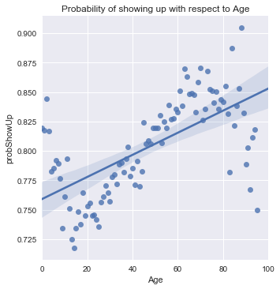

```python
sns.lmplot(data = prob_show(df, 'Age'), x = 'Age', y = 'probShowUp', fit_reg = True)
sns.plt.xlim(0, 100)
sns.plt.title('Probability of showing up with respect to Age')
sns.plt.show()
```

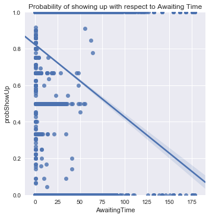

```python
sns.lmplot(data = prob_show(df, 'AwaitingTime'), x = 'AwaitingTime',
           y = 'probShowUp', fit_reg = True)
sns.plt.title('Probability of showing up with respect to Awaiting Time')
sns.plt.ylim(0, 1)
sns.plt.show()
```

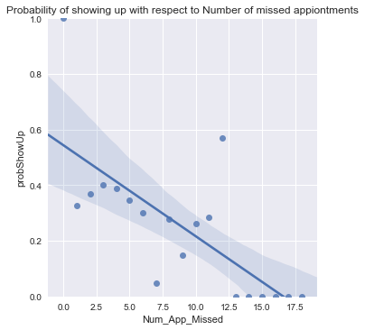

```python
sns.lmplot(data = prob_show(df, 'Num_App_Missed'), x = 'Num_App_Missed',
           y = 'probShowUp', fit_reg = True)
sns.plt.title('Probability of showing up with respect to Number of missed appiontments')
sns.plt.ylim(0, 1)
sns.plt.show()
```

Clearly, Number of missed appiontments and AwaitingTime and Age are good predictors of ٍShowing up,

```python
def prob_categorical(df, group_by):
    rows = []
    for item in group_by:
        #np.array((df[item] == level) & (df['No_show'] == 0), dtype = bool)
        for level in df[item].unique():
            row = {'Condition': item}
            total = len(df[df[item] == level])
            #n = len(df[(df[item] == level) & (df['No_show'] == 0)])
            n = len(np.array(df[(df[item] == level) & (df['No_show'] == 0)], dtype = bool))
            row.update({'Level': level, 'Probability': n / total})
            rows.append(row)
    return pd.DataFrame(rows)
```

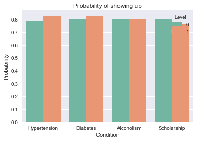

```python
sns.barplot(data = prob_categorical(df,['Hypertension', 'Diabetes', 'Alcoholism', 'Scholarship']),
            x = 'Condition', y = 'Probability', hue = 'Level', palette = 'Set2')
sns.plt.title('Probability of showing up')
sns.plt.ylabel('Probability')
sns.plt.show()
```

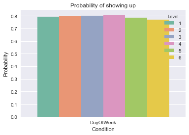

```python
sns.barplot(data = prob_categorical(df,['DayOfWeek']),
            x = 'Condition', y = 'Probability', hue = 'Level', palette = 'Set2')
sns.plt.title('Probability of showing up')
sns.plt.ylabel('Probability')
sns.plt.show()
```

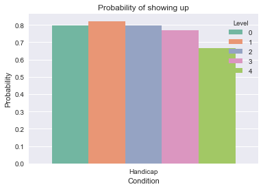

```python
sns.barplot(data = prob_categorical(df,['Handicap']),
            x = 'Condition', y = 'Probability', hue = 'Level', palette = 'Set2')
sns.plt.title('Probability of showing up')
sns.plt.ylabel('Probability')
sns.plt.show()
```

## Conclusions

- Certain age groups appear to be more likely to miss appointments.
- SMS reminder didn't increase show ups.
- Number of missed appiontments and AwaitingTime and Age are good predictors of ٍShowing up.
- Patients with scholarships (low income) appeared to have a higher percentage of not attending appointments.